# Feature Engineering Commentary

Jason Turk

2024-12-03

```r
library(here)
library(readr)
library(dplyr)
library(lubridate)
library(hms)
library(purrr)
```

```r
dir.create(here("data", "processed"), recursive = TRUE, showWarnings = FALSE)

data_raw_train <- readr::read_csv(here("data", "raw", "LC_train.csv"))
data_raw_test <- readr::read_csv(here("data", "raw", "LC_test.csv"))
colnames(data_raw_train)
```

```
##  [1] "Student_IDs"               "Semester"
##  [3] "Degree_Type"               "Class_Standing"
##  [5] "Major"                     "Expected_Graduation"
##  [7] "Course_Name"               "Course_Number"
##  [9] "Course_Type"               "Course_Code_by_Thousands"
## [11] "Semester_Week"             "Check_In_Date"
## [13] "Check_In_Time"             "Check_Out_Time"
## [15] "Duration_In_Min"           "Gender"
## [17] "Term_Credit_Hours"         "Term_GPA"
## [19] "Total_Credit_Hours_Earned" "Cumulative_GPA"
## [21] "Change_in_GPA"
```

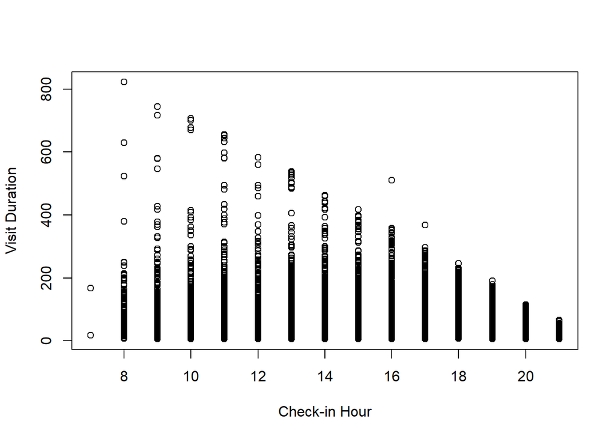

```r
prepare_dates <- function(df) {
  df %>% mutate(
    Check_In_Date = mdy(Check_In_Date),
    Check_In_Time = hms::as_hms(Check_In_Time)
  )
}

add_temporal_features <- function(df) {
  df %>% mutate(
    Check_In_Day = wday(Check_In_Date, label = TRUE),
    Is_Weekend = Check_In_Day %in% c("Sat", "Sun"),
    Check_In_Week = ceiling(day(Check_In_Date) / 7),
    Check_In_Month = month(Check_In_Date, label = TRUE),
    Check_In_Hour = hour(Check_In_Time)
  )
}

add_time_category <- function(df) {
  df %>% mutate(
    Time_Category = case_when(
      hour(Check_In_Time) < 6 ~ "Late Night",
      hour(Check_In_Time) < 12 ~ "Morning",
      hour(Check_In_Time) < 17 ~ "Afternoon",
      hour(Check_In_Time) < 22 ~ "Evening",
      TRUE ~ "Late Night"
    )
  )
}

convert_semester_to_date <- function(semester_str) {
  # Extract year and semester
  parts <- strsplit(semester_str, " ")[[1]]
  year <- parts[length(parts)]
  semester <- parts[1]

  # Map semesters to months
  month <- case_when(
    semester == "Fall" ~ "08",
    semester == "Spring" ~ "01",
    semester == "Summer" ~ "06",
    semester == "Winter" ~ "12",
    TRUE ~ NA_character_
  )

  # Combine into date
  paste0(month, "/", "01", "/", year)
}

add_date_features <- function(df) {
  df %>%
    mutate(
      # Convert semester to date
      Semester_Date = mdy(purrr::map(Semester, convert_semester_to_date)),
      # Convert expected graduation to date
      Expected_Graduation_Date = mdy(purrr::map(Expected_Graduation, convert_semester_to_date)),
    )
}

add_graduation_features <- function(df) {
  df %>% mutate(
    # Calculate months until graduation
    Months_Until_Graduation = as.numeric(
      difftime(Expected_Graduation_Date, Semester_Date, units = "days") / 30.44 # average days per month
    )
  )
}

plot(hour(data_raw_train$Check_In_Time), data_raw_train$Duration_In_Min, xlab = "Check-in Hour",ylab = "Visit Duration")
```

**The ‘Expected Graduation’ variable is a bit level-heavy as it stands. Our method to potentially improve upon this predictor is to convert it to a numeric ‘Months Until Graduation’ variable.**

```r
add_course_features <- function(df) {
  df %>% mutate(
    Course_Level = case_when(
      Course_Code_by_Thousands <= 100 ~ "Special",
      Course_Code_by_Thousands <= 3000 ~ "Lower Classmen",
      Course_Code_by_Thousands <= 4000 ~ "Upper Classmen",
      TRUE ~ "Graduate"
    )
  )
}

add_gpa_category <- function(df) {
  df %>% mutate(
    GPA_Category = case_when(
      Cumulative_GPA >= 3.5 ~ "Excellent",
      Cumulative_GPA >= 3.0 ~ "Good",
      Cumulative_GPA >= 2.0 ~ "Satisfactory",
      TRUE ~ "Needs Improvement"
    )
  )
}

add_credit_load_category <- function(df) {
  df %>% mutate(
    # Credit load features
    Credit_Load_Category = case_when(
      Term_Credit_Hours <= 6 ~ "Part Time",
      Term_Credit_Hours <= 12 ~ "Half Time",
      Term_Credit_Hours <= 18 ~ "Full Time",
      TRUE ~ "Overload"
    ),
  )
}

add_class_standing_category <- function(df) {
  df %>% mutate(
    # Renaming column and values for Class_Standing
    Class_Standing_Self_Reported = case_when(
      Class_Standing == "Freshman" ~ "First Year",
      Class_Standing == "Sophomore" ~ "Second Year",
      Class_Standing == "Junior" ~ "Third Year",
      Class_Standing == "Senior" ~ "Fourth Year",
      TRUE ~ Class_Standing
    ),
  )
}

add_class_standing_bgsu <- function(df) {
  df %>% mutate(
    # Class_standing by BGSU's definition
    # https://www.bgsu.edu/academic-advising/student-resources/academic-standing.html
    Class_Standing_BGSU = case_when(
      Total_Credit_Hours_Earned < 30 ~ "Freshman",
      Total_Credit_Hours_Earned < 60 ~ "Sophomore",
      Total_Credit_Hours_Earned < 90 ~ "Junior",
      Total_Credit_Hours_Earned <= 120 ~ "Senior",
      TRUE ~ "Extended"
    ),
  )
}
```

**The ‘Course Code by Thousands’ variable contains some ambiguities that make it a bit level-heavy when treated as a categorical variable, so we have categorized it into a ‘Course Level’ variable (“Special”, “Lower classmen”, “Upper classmen”, and “Graduate”). We have further categorized Cumulative_GPA to create a ‘GPA Category’ variable (< 2.0, 2.0-3.0, 3.0-3.5, and 3.5-4.0), and ‘Term Credit Hours’ to ‘Credit Load Category’ (“Part Time”, “Half Time”, “Full Time”, and “Overload”).**

**The excess of ‘Seniors’ present in the dataset appears to be because many of the students have obtained extraneous credits to acquire senior status but have not met the requirements to graduate in some form. To help reduce the volume of seniors we categorized those with 90-120 credit hours as ‘Senior’ and those with over 120 credit hours as ‘Extended’ (still seniors by definition but already above the necessary credits). The original Class Standing variable was recoded as ‘Class Standing Self Reported’ with labels “First Year” through “Fourth Year” (plus “Graduate” and “Other”) so that if there is any meaningful information in the original Class Standing variable it could be captured by our model.**

```r
add_course_name_category <- function(df) {
  df %>% mutate(
    Course_Name_Category = case_when(
      # Introductory level courses
      grepl("Algebra|Basic|Elementary|Intro|Introduction|Fundamental|General|Principles|Orientation",
            Course_Name, ignore.case = TRUE) ~ "Introductory",

      # Intermediate level courses
      grepl("Intermediate|II$|II |2|Applied",
            Course_Name, ignore.case = TRUE) ~ "Intermediate",

      # Advanced level courses
      grepl("Advanced|III|3|Analysis|Senior|Graduate|Dissertation|Research|Capstone", Course_Name, ignore.case = TRUE) ~ "Advanced",

      # Business related courses
      grepl("Business|Finance|Accounting|Economics|Marketing|Management",
            Course_Name, ignore.case = TRUE) ~ "Business",

      # Laboratory/Practical courses
      grepl("Laboratory|Lab", Course_Name, ignore.case = TRUE) ~ "Laboratory",

      # Seminar/Workshop courses
      grepl("Seminar|Workshop", Course_Name, ignore.case = TRUE) ~ "Seminar",

      # Independent/Special courses
      grepl("Independent|Special", Course_Name, ignore.case = TRUE) ~ "Independent Study",

      # Mathematics and Statistics
      grepl("Mathematics|Calculus|Statistics|Probability|Geometry|Discrete",
            Course_Name, ignore.case = TRUE) ~ "Mathematics",

      # Computer Science
      grepl("Computer|Programming|Data|Software|Network|Database|Algorithm",
            Course_Name, ignore.case = TRUE) ~ "Computer Science",

      # Natural Sciences
      grepl("Physics|Chemistry|Biology|Astronomy|Earth|Environment|Science",
            Course_Name, ignore.case = TRUE) ~ "Natural Sciences",

      # Social Sciences
      grepl("Psychology|Sociology|Anthropology|Social|Cultural|Society",
            Course_Name, ignore.case = TRUE) ~ "Social Sciences",

      # Humanities
      grepl("History|Philosophy|Ethics|Literature|Culture|Language|Art",
            Course_Name, ignore.case = TRUE) ~ "Humanities",

      # Education/Teaching
      grepl("Education|Teaching|Learning|Childhood|Teacher|Curriculum",
            Course_Name, ignore.case = TRUE) ~ "Education",

      # Default case
      TRUE ~ "Other"
    )
  )
}
```

**The ‘Course Name’ variable is completely unusable in its current state and needs some kind of categorization to be effective. While there are many possible approaches to doing so, ours is a bit more flexible in that we create 14 different possible levels using keywords present in the course names (for example, a class with ‘Culture’, ‘Language’, or ‘Ethics’ (among other things) in its name would be listed as ‘Humanities’. Though a variable with this many levels may suffer in some types of model fitting, it allows us to be more flexible if desired; regularization and variable selection can be utilized in the model building process if needed.**

```r
add_course_type_category <- function(df) {
  df %>% mutate(
    Course_Type_Category = case_when(
      # STEM Fields
      Course_Type %in% c("MATH", "STAT", "CS", "ASTR","PHYS", "BIOL", "CHEM", "GEOL", "ECET") ~ "STEM Core",

      # Engineering and Technology
      Course_Type %in% c("ENGT", "CONS", "ARCH", "MIS", "TECH") ~ "Engineering & Technology",

      # Business and Economics
      Course_Type %in% c("FIN", "ACCT", "ECON", "BA", "MGMT", "MKT", "MBA", "BIZX", "LEGS", "OR") ~ "Business",

      # Social Sciences
      Course_Type %in% c("SOC", "PSYC", "POLS", "CRJU", "HDFS", "SOWK", "GERO") ~ "Social Sciences",

      # Natural and Health Sciences
      Course_Type %in% c("NURS", "MLS", "EXSC", "FN", "AHTH", "DHS") ~ "Health Sciences",

      # Humanities and Languages
      Course_Type %in% c("HIST", "PHIL", "ENG", "GSW", "FREN", "GERM", "SPAN", "LAT", "RUSN", "ITAL", "CLCV") ~ "Humanities",

      # Arts and Performance
      Course_Type %in% c("ART", "ID", "MUCT", "MUS", "THFM", "POPC") ~ "Arts",

      # Education and Teaching
      Course_Type %in% c("EDTL", "EDFI", "EDIS", "EIEC") ~ "Education",

      # Environmental Studies
      Course_Type %in% c("ENVS", "GEOG", "SEES") ~ "Environmental Studies",

      # Special Programs
      Course_Type %in% c("HNRS", "UNIV", "ORGD", "RESC") ~ "Special Programs",

      # Physical Education
      Course_Type %in% c("PEG", "SM", "HMSL") ~ "Physical Education",

      # Cultural Studies
      Course_Type %in% c("ETHN", "COMM", "CDIS") ~ "Cultural & Communication Studies",

      # No Response/Unknown
      Course_Type %in% c("No Response", NA) ~ "No Response",

      # Default case
      TRUE ~ "Other"
    )
  )
}
```

**The ‘Course Type’ variable is also unusable in its current state and needs a reduction in levels; some natural categorizations (14 total) for this variable are business courses, education courses, and STEM courses. “No Response” is given to those individuals who did not report a specific course as the reason for their visit to the Learning Commons.**

```r
add_major_category <- function(df) {
  df %>% mutate(
    Major_Category = case_when(
      # Business and Management
      grepl("MBA|BSBA|Business|Marketing|Finance|Account|Economics|Management|Supply Chain|Analytics",
            Major, ignore.case = TRUE) ~ "Business",

      # Computer Science and Technology
      grepl("Computer|Software|Data|Information Systems|Technology|Engineering|Electronics",
            Major, ignore.case = TRUE) ~ "Computing & Technology",

      # Natural Sciences
      grepl("Biology|Chemistry|Physics|Science|Environmental|Geology|Forensic|Neuroscience",
            Major, ignore.case = TRUE) ~ "Natural Sciences",

      # Health Sciences
      grepl("Nursing|Health|Medical|Nutrition|Dietetics|Physical Therapy|Physician|Laboratory",
            Major, ignore.case = TRUE) ~ "Health Sciences",

      # Social Sciences
      grepl("Psychology|Sociology|Criminal Justice|Political|Economics|Social Work|Anthropology",
            Major, ignore.case = TRUE) ~ "Social Sciences",

      # Education
      grepl("Education|Teaching|Early Childhood|BSED|Intervention Specialist",
            Major, ignore.case = TRUE) ~ "Education",

      # Arts and Humanities
      grepl("Art|Music|Philosophy|History|English|Language|Communication|Media|Journalism|Film|Theatre",
            Major, ignore.case = TRUE) ~ "Arts & Humanities",

      # Mathematics and Statistics
      grepl("Math|Statistics|Actuarial",
            Major, ignore.case = TRUE) ~ "Mathematics",

      # Pre-Professional Programs
      grepl("Pre-|PRELAW|PREMED|PREVET",
            Major, ignore.case = TRUE) ~ "Pre-Professional",

      # Undecided/General Studies
      grepl("Undecided|Liberal Studies|General|Deciding|UND|Individual|BLS",
            Major, ignore.case = TRUE) ~ "General Studies",

      # Special Programs
      grepl("Minor|Certificate|GCERT|Non-Degree",
            Major, ignore.case = TRUE) ~ "Special Programs",

      # No Response/Unknown
      grepl("No Response|NA", Major, ignore.case = TRUE) ~ "No Response",

      # Default case
      TRUE ~ "Other"
    ),

    # Add a flag for double majors
    Has_Multiple_Majors = grepl(",", Major)
  )
}
```

**Lastly, another complex variable that needs to be category-reduced is the ‘Major’ variable. Using a similar approach as in ‘Course Name’, we create categories by recognizing similar keywords among the major names and placing them into larger groups. Some examples include ‘Mathematics’ (which includes math majors, statistics majors, and actuarial science majors), ‘Business’, and ‘Social Sciences’. An ‘Other’ case is left as a catchall for those majors that do not fall into any of the broader categories. We are also able to create a ‘Multiple Majors’ indicator variable by checking if the ‘Major’ variable is a comma-separated list.**

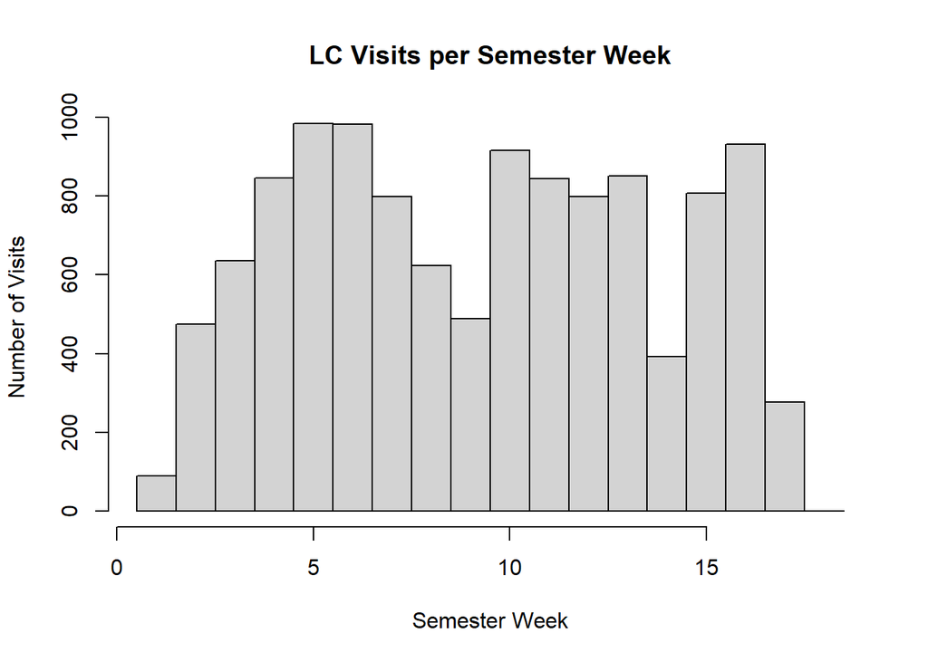

```r
add_visit_features <- function(df) {
  df %>%
    group_by(Student_IDs) %>%
    mutate(
      # Count visits per student
      Total_Visits = n(),
      # Count visits per student per semester
      Semester_Visits = n_distinct(Check_In_Date),
      # Average visits per week
      Avg_Weekly_Visits = Semester_Visits / max(Semester_Week)
    ) %>%
    ungroup()
}

add_week_volume_category <- function(df) {
  df %>%
    mutate(
      Week_Volume = case_when(
        Semester_Week %in% c(4:8, 10:13, 15:16) ~ "High Volume",
        Semester_Week %in% c(1:3, 9, 14, 17) ~ "Low Volume",
        TRUE ~ "Other"
      )
    )
}

SW <- hist(data_raw_train$Semester_Week, plot = F, breaks = seq(0,18))
SW$breaks <- SW$breaks + diff(SW$breaks)[1]/2
plot(SW,  main = "LC Visits per Semester Week", xlab = "Semester Week", ylab = "Number of Visits")
```

**Using the student ID index, we can also track how many total visits a student makes to the Learning Commons, as well as their Semester Visits and Average Weekly Visits. Based on ‘Semester Week’ visit frequency we can classify some weeks as ‘High Volume’ and others as ‘Low Volume’ as the volume of visits in a given week may influence how long someone stays at the Learning Commons; weeks 1-3, 9, 14, and 17 are treated as ‘Low Volume’ (by inspection) and the rest are treated as ‘High Volume’.**

```r
add_course_load_features <- function(df) {
  df %>%
    group_by(Student_IDs, Semester) %>%
    mutate(
      # Number of unique courses
      Unique_Courses = n_distinct(Course_Number),
      # Mix of course levels
      Course_Level_Mix = n_distinct(Course_Code_by_Thousands),
      # Proportion of advanced courses
      Advanced_Course_Ratio = mean(Course_Level == "Upper Classmen", na.rm = TRUE)
    ) %>%
    ungroup()
}

add_gpa_trend <- function(df) {
  df %>% mutate(
    # Calculate GPA trend (1 for positive, -1 for negative, 0 for no change)
    GPA_Trend = sign(Change_in_GPA),
  )
}
```

**We can further check how many unique courses a student is taking in a given semester, the number of different course levels (based on the ‘Course Code by Thousands’ variable) they are taking in a given semester, and the proportion of courses which are considered ‘Upper Classmen’ (4000-level), creating one new feature for each. We can further make an indicator of the sign of the ‘Change in GPA’ variable in case the actual numeric information in that variable is of less importance than just the direction the students’ GPA is trending in the semester in which they visit.**

```r
ensure_duration <- function(df) {
  # Calculate duration in minutes
  df %>%
    mutate(
      Duration_In_Min = as.numeric(difftime(
        Check_Out_Time,
        Check_In_Time,
        units = "mins"
      )),
      # Filter out negative durations
      Duration_In_Min = if_else(Duration_In_Min < 0, NA_real_, Duration_In_Min),
    ) %>%
    filter(!is.na(Duration_In_Min))
}

calculate_occupancy <- function(df) {
  df %>%
    arrange(Check_In_Date, Check_In_Time) %>%
    group_by(Check_In_Date) %>%
    mutate(
      Cum_Arrivals = row_number(),
      Cum_Departures = sapply(seq_along(Check_In_Time), function(i) {
        sum(!is.na(Check_Out_Time[1:i]) &
            Check_Out_Time[1:i] <= Check_In_Time[i])
      }),
      Occupancy = Cum_Arrivals - Cum_Departures
    ) %>%
    select(-c(Cum_Arrivals, Cum_Departures))
}
```

**Here we ran a checksum to make sure that Duration_in_Min was computed correctly based on the check-in and check-out times for each visit (and did not have any negative values), and created the ‘Occupancy’ variable needed for part (b).**

```r
add_group_features <- function(df) {
  df %>%
    mutate(
      Check_In_Timestamp = ymd_hms(paste(Check_In_Date, Check_In_Time))
    ) %>%
    add_count(Check_In_Timestamp, name = "Group_Size") %>%
    mutate(
      Group_Check_In = Group_Size > 1,
      Group_Size_Category = case_when(
        Group_Size == 1 ~ "Individual",
        Group_Size <= 3 ~ "Small Group",
        Group_Size <= 6 ~ "Medium Group",
        TRUE ~ "Large Group"
      )
    ) %>%
    select(-Check_In_Timestamp)
}
```

```r
safely_mutate <- function(df, mutation_fn, required_cols) {
  # Check if all required columns exist
  missing_cols <- setdiff(required_cols, names(df))

  if (length(missing_cols) > 0) {
    warning(sprintf("Skipping mutation: Missing columns: %s",
                   paste(missing_cols, collapse = ", ")))
    return(df)
  }

  tryCatch({
    mutation_fn(df)
  }, error = function(e) {
    warning(sprintf("Error in mutation: %s", e$message))
    return(df)
  })
}

# Modify the engineer_features function
engineer_features <- function(df) {
  df %>%
    safely_mutate(prepare_dates,
                 c("Check_In_Date", "Check_In_Time")) %>%
    safely_mutate(add_date_features,
                 c("Semester", "Expected_Graduation")) %>%
    safely_mutate(add_temporal_features,
                 c("Check_In_Date", "Check_In_Time")) %>%
    safely_mutate(add_time_category,
                 c("Check_In_Hour")) %>%
    safely_mutate(add_course_features,
                 c("Course_Code_by_Thousands")) %>%
    safely_mutate(add_course_name_category,
                 c("Course_Name")) %>%
    safely_mutate(add_course_type_category,
                 c("Course_Type")) %>%
    safely_mutate(add_major_category,
                 c("Major")) %>%
    safely_mutate(add_gpa_category,
                 c("Cumulative_GPA")) %>%
    safely_mutate(add_credit_load_category,
                 c("Term_Credit_Hours")) %>%
    safely_mutate(add_class_standing_category,
                 c("Class_Standing")) %>%
    safely_mutate(add_class_standing_bgsu,
                 c("Total_Credit_Hours_Earned")) %>%
    safely_mutate(ensure_duration,
                 c("Check_In_Time")) %>%
    safely_mutate(add_visit_features,
                 c("Student_IDs", "Check_In_Date", "Semester_Week")) %>%
    safely_mutate(add_week_volume_category,
                 c("Semester_Week")) %>%
    safely_mutate(add_graduation_features,
                 c("Expected_Graduation_Date", "Semester_Date")) %>%
    safely_mutate(add_course_load_features,
                 c("Student_IDs", "Semester", "Course_Number",
                   "Course_Code_by_Thousands", "Course_Level")) %>%
    safely_mutate(add_gpa_trend,
                 c("Change_in_GPA")) %>%
    safely_mutate(add_group_features,
                 c("Check_In_Date", "Check_In_Time")) %>%
    safely_mutate(calculate_occupancy,
                 c("Check_In_Date", "Check_In_Time", "Check_Out_Time")) %>%
    ungroup()
}

lc_engineered_train <- engineer_features(data_raw_train)
lc_engineered_test <- engineer_features(data_raw_test)
colnames(lc_engineered_train)
```

```
##  [1] "Student_IDs"                  "Semester"
##  [3] "Degree_Type"                  "Class_Standing"
##  [5] "Major"                        "Expected_Graduation"
##  [7] "Course_Name"                  "Course_Number"
##  [9] "Course_Type"                  "Course_Code_by_Thousands"
## [11] "Semester_Week"                "Check_In_Date"
## [13] "Check_In_Time"                "Check_Out_Time"
## [15] "Duration_In_Min"              "Gender"
## [17] "Term_Credit_Hours"            "Term_GPA"
## [19] "Total_Credit_Hours_Earned"    "Cumulative_GPA"
## [21] "Change_in_GPA"                "Semester_Date"
## [23] "Expected_Graduation_Date"     "Check_In_Day"
## [25] "Is_Weekend"                   "Check_In_Week"
## [27] "Check_In_Month"               "Check_In_Hour"
## [29] "Time_Category"                "Course_Level"
## [31] "Course_Name_Category"         "Course_Type_Category"
## [33] "Major_Category"               "Has_Multiple_Majors"
## [35] "GPA_Category"                 "Credit_Load_Category"
## [37] "Class_Standing_Self_Reported" "Class_Standing_BGSU"
## [39] "Total_Visits"                 "Semester_Visits"
## [41] "Avg_Weekly_Visits"            "Week_Volume"
## [43] "Months_Until_Graduation"      "Unique_Courses"
## [45] "Course_Level_Mix"             "Advanced_Course_Ratio"
## [47] "GPA_Trend"                    "Group_Size"
## [49] "Group_Check_In"               "Group_Size_Category"
## [51] "Occupancy"
```

**Above is the final set of predictors we will use for model building.**